# 2.6 - Notas de Luis sobre la construcción de nuestro primer modelo predictivo

¡Muy bien equipo, aquí Luis!

La sesión de pizarra de Carmen sobre regresión lineal fue un plan brillante. Ahora me toca a mí traducir eso a código real. Vamos a construir nuestro primer modelo predictivo para Minermont, desde cero. Inicialmente, no usaremos bibliotecas sofisticadas que hagan la magia por nosotros; quiero que entendamos *exactamente* cómo aprende esto.

Este es nuestro primer proyecto de software real en nuestro viaje de IA. Manos a la obra y escribamos código que funcione, sea fácil de leer y resuelva un problema real: predecir las necesidades de mascarillas.

Aquí está mi plan, paso a paso:

1. Importando las bibliotecas necesarias
2. Preparando los Datos (Preparando los Datos)
3. El Cerebro de la Operación (Los Componentes del Modelo)
4. Cómo Aprende el Código (El Bucle de Entrenamiento)
5. Verificando Nuestro Trabajo (Visualizando los Resultados)
6. Poniéndolo en Uso (Usando Nuestro Modelo para Predecir)

### Paso 1: ¿Qué Herramientas Necesitamos? (Importando Bibliotecas)

Primero lo primero, tomemos nuestras herramientas. Lo mantendremos simple con solo dos bibliotecas principales de Python.

- `numpy`: Este es nuestro caballo de batalla numérico. Lo usaremos para manejar arreglos de datos y hacer el trabajo pesado de las matemáticas. Piénsalo como la base.
- `matplotlib`: Tenemos que ver lo que está pasando, ¿verdad? Esto es para graficar nuestros datos y visualizar los resultados. ¡No puedes arreglar lo que no puedes ver!

```python
# Bloque de Código 1: Importando nuestras bibliotecas

import numpy as np
import matplotlib.pyplot as plt

# Una rápida impresión para confirmar que todo está cargado y listo. ¡Buena práctica!
print("Kit de herramientas listo. NumPy y Matplotlib están cargados y listos.")
```

```
Kit de herramientas listo. NumPy y Matplotlib están cargados y listos.
```

### Paso 2: Preparación de los datos

Nuestro modelo necesita datos para aprender. Mientras Sophia y Ethan trabajan con la base de datos real del hospital, yo estoy creando un conjunto de datos "sintéticos". Actuará como si fuera real, imitando la relación entre pacientes (x) y mascarillas necesarias (y), pero con un toque aleatorio para que parezca real.

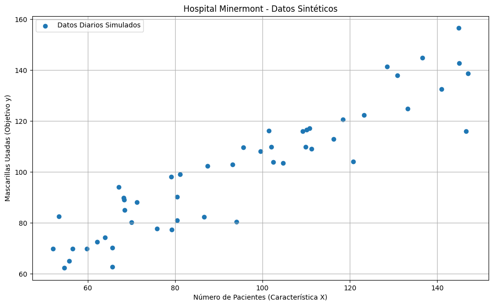

```python
# Bloque de Código 2: Creando un conjunto de datos sintético y realista

# Estoy configurando una 'semilla aleatoria' aquí. Este es un paso crucial en la ingeniería de software
# para el aprendizaje automático. Asegura que nuestros números 'aleatorios' sean los mismos cada
# vez que ejecutamos este código, haciendo que nuestros resultados sean reproducibles.
np.random.seed(42)

# Simulemos datos para 50 días.
m = 50 # 'm' es el nombre de variable estándar para el número de ejemplos de entrenamiento.

# X = Número de Pacientes. Creemos 50 valores aleatorios entre 50 y 150.
# La forma (m, 1) lo convierte en un vector columna, lo cual es una buena práctica para ML.
X = 50 + 100 * np.random.rand(m, 1)

# y = Número de Mascarillas Usadas.
# Creemos una relación: y = 25 (base) + 0.8 * X + algo de ruido aleatorio.
# Esto simula un escenario del mundo real donde la relación no es perfectamente lineal.
y = 25 + 0.8 * X + np.random.randn(m, 1) * 10

# Lo primero que debe hacer un desarrollador con los datos es mirarlos.
# Grafiquémoslos para confirmar visualmente que se ven como esperamos.
plt.figure(figsize=(12, 7))
plt.scatter(X, y, label='Datos Diarios Simulados')
plt.title("Hospital Minermont - Datos Sintéticos")
plt.xlabel("Número de Pacientes (Característica X)")
plt.ylabel("Mascarillas Usadas (Objetivo y)")
plt.grid(True)
plt.legend()
plt.show()
```

### Paso 3: El Cerebro de la Operación (Los Componentes del Modelo)

- La Hipótesis ($h(x)$): Esta es nuestra función de predicción. Para la regresión lineal, es solo la ecuación de una línea. La llamaré `prediction()`. $$prediction(x) = w * x + b$$ $w$ (peso) y $b$ (sesgo) son los parámetros que nuestro modelo aprenderá. Estos son los "mandos" que ajustaremos.
- La Función de Costo ($J(w, b$)): Esto nos dice cuán "equivocadas" están las predicciones de nuestro modelo. Cuanto menor, mejor. Usaremos el Error Cuadrático Medio (MSE), una elección bastante estándar. $$cost = averageOf( (prediction - actualvalue)^2 )$$
- Descenso de Gradiente: Este es el proceso de aprendizaje en sí. Ajusta automáticamente $w$ y $b$ para minimizar el costo. Descubre la "pendiente" de la función de costo y da pasos cuesta abajo.

### Paso 4: Cómo Aprende el Código (El Bucle de Entrenamiento)

Este es el corazón de nuestro programa, la sala de máquinas. Inicializaremos nuestros parámetros y luego ejecutaremos un bucle que los refinará repetidamente utilizando el Descenso de Gradiente. Comentaré cada línea para que puedas ver exactamente lo que está sucediendo.

**Al tratarse de una muestra de datos muy pequeña con solo 50 elementos y para mantener el codigo senzillo, utilizaremos el descenso por lotes utilizando las 50 entradas en cada iteración.**

```python
# Bloque de Código 3: Construyendo y Entrenando el Modelo (con Detención Temprana)

# --- 1. Inicialización de Parámetros ---
# Necesitamos darle a nuestro modelo un punto de partida. Empecemos w y b en 0.
# Es una posición inicial simple y neutral.
w = 0.0
b = 0.0

# --- 2. Configuración de Hiperparámetros ---
# Estos son ajustes para el algoritmo de aprendizaje, no aprendidos de los datos.
# Tenemos que configurarlos nosotros mismos.
learning_rate = 0.0001     # Qué tan grande es el paso a dar en cada actualización. Un valor pequeño es más seguro.
num_iterations = 10000      # El número máximo de iteraciones.
alpha = 0.001              # Cambio mínimo en el costo para seguir adelante (umbral de detención temprana).

# --- 3. El Bucle de Entrenamiento ---
# Almacenaremos el costo en cada paso para observar cómo aprende nuestro modelo.
cost_log = []

print("Iniciando la secuencia de entrenamiento...")
for i in range(num_iterations):
    # a) Realizar predicciones para TODOS nuestros puntos de datos con los w y b actuales.
    y_pred = w * X + b

    # b) Calcular el costo (MSE) para estas predicciones.
    # Esto nos dice qué tan bien lo estamos haciendo en esta iteración.
    cost = np.mean((y_pred - y)**2)
    cost_log.append(cost)

    # --- Condición de Detención Temprana ---
    # Si el costo no ha cambiado mucho en comparación con el paso anterior,
    # significa que hemos alcanzado una región plana, no estamos aprendiendo mucho más.
    if i > 0 and abs(cost_log[-2] - cost_log[-1]) < alpha:
        print(f"Deteniendo temprano en la iteración {i} debido a un pequeño cambio en el costo.")
        break

    # c) Calcular los gradientes. Este es el núcleo del aprendizaje.
    # Estas fórmulas provienen de la derivada de cálculo de la función de costo.
    # Nos dicen la pendiente de nuestra "colina" de costo para w y b.
    dw = (1/m) * np.sum((y_pred - y) * X)  # Gradiente para el peso
    db = (1/m) * np.sum(y_pred - y)        # Gradiente para el sesgo

    # d) Actualizar los parámetros.
    # Movemos w y b en la dirección *opuesta* a su gradiente.
    # Este es el paso "cuesta abajo".
    w = w - learning_rate * dw
    b = b - learning_rate * db

    # Un registro simple para monitorear el proceso en tiempo real.
    # Imprimimos la evolución del error cada 100 iteraciones
    # Empezamos imprimiendo la primera iteración ya que el error en 0 no es significativo al ser w y b aleatorios
    if ((i-1) % 100) == 0:
        print(f"Iteración {i}: Costo = {cost:.6f}")

# imprimir el número de iteraciones y el error final
print("\n--- Entrenamiento Completo ---")
print(f"Número de iteraciones: {i}")
print(f"Error final: {cost:.6f}")
print(f"Peso aprendido final (w): {w:.4f}")
print(f"Sesgo aprendido final (b): {b:.4f}")
```

```
Iniciando la secuencia de entrenamiento...
Iteración 1: Costo = 149.453144
Iteración 101: Costo = 143.590561
Iteración 201: Costo = 143.488009
Iteración 301: Costo = 143.385628
Iteración 401: Costo = 143.283419
Iteración 501: Costo = 143.181381
Iteración 601: Costo = 143.079514
Iteración 701: Costo = 142.977817
Iteración 801: Costo = 142.876291
Iteración 901: Costo = 142.774934
Iteración 1001: Costo = 142.673747
Iteración 1101: Costo = 142.572729
Iteración 1201: Costo = 142.471881
Iteración 1301: Costo = 142.371201
Iteración 1401: Costo = 142.270689
Iteración 1501: Costo = 142.170346
Iteración 1601: Costo = 142.070171
Deteniendo temprano en la iteración 1657 debido a un pequeño cambio en el costo.

--- Entrenamiento Completo ---
Número de iteraciones: 1657
Error final: 142.014146
Peso aprendido final (w): 1.0363
Sesgo aprendido final (b): 0.3832
```

### Paso 5: Verificando Nuestro Trabajo (Visualizando los Resultados)

Okay, hemos construido el motor. Pero, ¿realmente está funcionando? En aprendizaje automático, tenemos que visualizar.

Primero, grafiquemos la curva de aprendizaje. Esto muestra cómo el costo disminuye con el tiempo. ¡Si este gráfico no baja, algo anda mal!

Luego, graficaremos la línea final que nuestro modelo aprendió sobre los datos originales. Esta es la verificación visual definitiva para ver qué tan bien se ajusta.

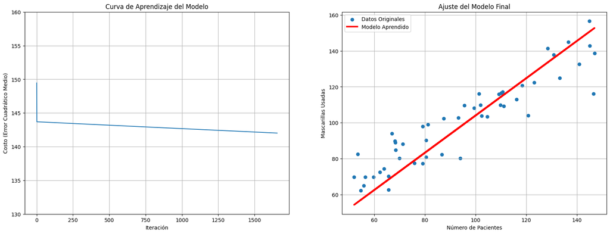

```python
# Bloque de Código 4: Visualizando el Rendimiento del Modelo

# Crea una figura con dos gráficos lado a lado para un informe agradable.
fig, (ax1, ax2) = plt.subplots(1, 2, figsize=(20, 7))

# elimina el primer valor del registro de costo, ya que en el primer paso w y b eran 0
# y este costo no es representativo
cost_log.pop(0)

# --- Gráfico 1: La Curva de Aprendizaje ---
ax1.plot(cost_log)
ax1.set_ylim(130, 160) # Establece el eje y a partir de los errores anteriores
ax1.set_title("Curva de Aprendizaje del Modelo")
ax1.set_xlabel("Iteración")
ax1.set_ylabel("Costo (Error Cuadrático Medio)")
ax1.grid(True)

# --- Gráfico 2: La Línea de Regresión Final ---
# Primero, grafica los puntos de datos originales
ax2.scatter(X, y, label='Datos Originales')
# Luego, grafica la línea que nuestro modelo aprendió
# Generamos los valores y para la línea usando nuestros w y b finales
ax2.plot(X, w * X + b, color='red', linewidth=3, label='Modelo Aprendido')
ax2.set_title("Ajuste del Modelo Final")
ax2.set_xlabel("Número de Pacientes")
ax2.set_ylabel("Mascarillas Usadas")
ax2.grid(True)
ax2.legend()

plt.show()
```

### Paso 6: Poniéndolo en Uso (Usando Nuestro Modelo para Predecir)

¡Muy bien, el objetivo era construir algo útil! Ahora que nuestro modelo está entrenado, usémoslo para predecir las necesidades de mascarillas para nuevos escenarios.

Esta es la recompensa: tomar nuestros `w` y `b` entrenados y conectarlos a nuestra simple ecuación de línea.

```python
# Bloque de Código 5: Haciendo una Predicción

# Digamos que Ethan quiere saber cuántas mascarillas debe presupuestar si esperamos 100 pacientes mañana.
patients_tomorrow = 100

# Usamos nuestros w y b finales entrenados para calcular la predicción.
predicted_masks = w * patients_tomorrow + b

print("\n--- Haciendo una Nueva Predicción ---")
print(f"Para un día con {patients_tomorrow} pacientes...")
print(f"Nuestro modelo predice que necesitaremos aproximadamente {int(predicted_masks)} mascarillas.")

# Probemos otra para un día más tranquilo.
patients_quiet_day = 65
predicted_masks_quiet = w * patients_quiet_day + b
print(f"\nPara un día con {patients_quiet_day} pacientes...")
print(f"Nuestro modelo predice que necesitaremos aproximadamente {int(predicted_masks_quiet)} mascarillas.")
```

```
--- Haciendo una Nueva Predicción ---
Para un día con 100 pacientes...
Nuestro modelo predice que necesitaremos aproximadamente 104 mascarillas.

Para un día con 65 pacientes...
Nuestro modelo predice que necesitaremos aproximadamente 67 mascarillas.
```

# Conclusión

Y ahí lo tienen. Construimos una máquina de aprendizaje desde cero. Tomamos un concepto teórico y diseñamos una solución funcional.

Ahora tenemos una herramienta, ¡nuestra primera! – para ayudar a Minermont a tomar decisiones basadas en datos. Es simple, pero sólida. Y como la construimos nosotros mismos, sabemos exactamente cómo funciona, sus limitaciones y cómo mejorarla.

Esto es solo el comienzo. Podemos construir cualquier cosa a partir de aquí.